# Arbeitspaket (AP) 3: Machine Learning (ML)

#### **Aufgabe (6): Erstellen Sie ein Random Forest Regression Model für die Vorhersage der Smartphone Preise.**

**Details zur Aufgabenstellung:**

- Verwenden Sie den Python Code in der folgenden Codezelle, um die Trainings- und Testdaten einzulesen.
- Erstellen und Trainieren Sie ein Random Forest Regression Model mit 500 einzelnen Trees und einer maximalen Tiefe von 5.
- Erstellen Sie eine Vorhersage der Preise für die Testdaten (X_test).
- Berechnen Sie die Vorhersagegüte mit Hilfe des r-squared (coefficient of determination).
- Stellen Sie die Feature Importance mit Hilfe eines Barcharts graphisch dar.

**(max. erreichbare Punkte: 8)**

```
R-squared: 0.3019
```

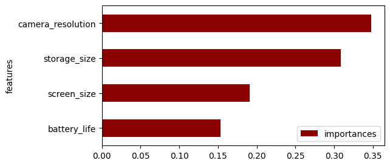

```python
# Einlesen der Trainings- und Testdaten (damit alle die gleichen Daten haben)
X_train = pd.read_csv('./Data/X_train.csv')
X_test = pd.read_csv('./Data/X_test.csv')
y_train = pd.read_csv('./Data/y_train.csv')
y_test = pd.read_csv('./Data/y_test.csv')

# Erstellen/Initialisieren eines 'random forest regressor' Objekts
reg_rf = RandomForestRegressor(n_estimators=500,
                               max_depth=5,
                               random_state=42)

# Trainieren des 'random forest regressor' Objekts
reg_rf.fit(X_train, y_train)

# Vorhersage der Preise für die Testdaten X_test
y_pred = reg_rf.predict(X_test)

# Berechnen des r-squared (coefficient of determination)
print('R-squared:', round(reg_rf.score(X_test, y_test), 4))

# Graphische Darstellung der Feature Importance
cols = X_train.columns

importances = reg_rf.feature_importances_
std         = np.std([tree.feature_importances_ for tree in reg_rf.estimators_], axis=0)
indices     = np.argsort(importances)[::-1]


# Barplot with feature importance
df_fi = pd.DataFrame({'features':cols,'importances': importances})
df_fi.sort_values('importances', inplace=True)
df_fi.plot(kind='barh',
           y='importances',
           x='features',
           color='darkred',
           figsize=(6,3))

plt.show()
```

#### **Aufgabe (7): Erstellen Sie ein Random Forest Classification Model für die Vorhersage der Hersteller.**

**Details zur Aufgabenstellung:**

- Verwenden Sie den Python Code in der folgenden Codezelle, um die Trainings- und Testdaten für die Klassifikation einzulesen.
- Die Zielvariable in diesem Modell ist die Variable make (Hersteller).
- Die erklärenden Variablen in diesem Modell sind: price, camera_resolution, battery_life, storage_size, screen_size.
- Erstellen und Trainieren Sie ein Random Forest Classification Model.
- Erstellen Sie eine Vorhersage der Zielvariable auf der Basis der Testdaten (X_test).
- Erstellen Sie eine Confusion Matrix, und stellen Sie diese im Jupyter Notebook dar.
- Erstellen Sie einen Classification report, und stellen Sie diesen im Jupyter Notebook dar.
- Beantworten Sie die Frage: Wie hoch ist der Anteil der Hersteller welche vom Modell korrekt klassifiziert wurden?
- Verwenden Sie für die Beantwortung der Frage die vorgefertigte print() Funktion (Ersetzen Sie '... %').

**(max. erreichbare Punkte: 8)**

```python
# Einlesen der Trainings- und Testdaten (damit alle die gleichen Daten haben)
X_train = pd.read_csv('./Data/X_train_class.csv')
X_test = pd.read_csv('./Data/X_test_class.csv')
y_train = pd.read_csv('./Data/y_train_class.csv')
y_test = pd.read_csv('./Data/y_test_class.csv')

# Umformen der y_train and y_test zu 1-dimensional arrays
y_train = y_train.values.ravel()
y_test = y_test.values.ravel()

# Erstellen/Initialisieren des 'random forest classifier' Objekts
rfc = RandomForestClassifier(n_estimators=500, random_state=42, max_depth=5)

# Trainieren des Random Forest Classification Modells
rfc = rfc.fit(X_train, y_train)

# Vorhersage der Zielvariable für die Testdaten X_test
y_pred_rf = rfc.predict(X_test)

# Confusion matrix
print('Confusion matrix')
print(confusion_matrix(y_test, y_pred_rf), '\n')

# Classification report
print('Classification report')
print(classification_report(y_test, y_pred_rf))

# Beantworten der Frage: Wieviel % der Hersteller wurden korrekt klassifiziert?
print(f'\nDer Anteil der vom Modell korrekt klassifizierten Hersteller beträgt 31 %.')
```

```
Confusion matrix
[[135  13   6  42  11]
 [ 86  25  22  48  25]
 [ 64  27  19  77  30]
 [ 20  23  12 108  14]
 [ 40  17  18  94  24]]

Classification report
              precision    recall  f1-score   support

       Apple       0.39      0.65      0.49       207
      Google       0.24      0.12      0.16       206
     Samsung       0.25      0.09      0.13       217
        Vivo       0.29      0.61      0.40       177
      Xiaomi       0.23      0.12      0.16       193

    accuracy                           0.31      1000
   macro avg       0.28      0.32      0.27      1000
weighted avg       0.28      0.31      0.26      1000


Der Anteil der vom Modell korrekt klassifizierten Hersteller beträgt 31 %.
```

#### **Aufgabe (8): Erstellen Sie ein Random Forest Classification Model für die Vorhersage der beiden Hersteller 'Apple' und 'Vivo'.**

**Details zur Aufgabenstellung:**

- Es handelt sich bei diesem Beispiel um ein Klassifikationsproblem mit zwei Klassen ('Apple' und 'Vivo').
- Ergänzen Sie den Python Code dort wo notwendig.
- Beantworten Sie mit eigenen Worten die Frage: Wie gut ist das Modell darin, Smartphones von Apple und Vivo zu unterscheiden?
- Verwenden Sie für die Beantwortung der Frage die vorgefertigte print() Funktion (Ersetzen Sie die '...').

**(max. erreichbare Punkte: 8)**

```
Confusion matrix
[[152  55]
 [ 47 130]]

Classification report
              precision    recall  f1-score   support

       Apple       0.76      0.73      0.75       207
        Vivo       0.70      0.73      0.72       177

    accuracy                           0.73       384
   macro avg       0.73      0.73      0.73       384
weighted avg       0.74      0.73      0.73       384
```

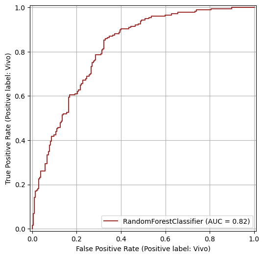

```
Das Modell ist [akzeptabel] darin, Smartphones von Apple und Vivo zu unterscheiden, da die AUC bei 0.82 liegt.
```

```python
# Einlesen der Trainings- und Testdaten (damit alle die gleichen Daten haben)
X_train = pd.read_csv('./Data/X_train_class.csv')
X_test = pd.read_csv('./Data/X_test_class.csv')
y_train = pd.read_csv('./Data/y_train_class.csv')
y_test = pd.read_csv('./Data/y_test_class.csv')

# Subset der Trainings- und Testdaten erstellen (nur zwei Hersteller)
X_train_subset = X_train[y_train['make'].isin(['Apple', 'Vivo'])]
y_train_subset = y_train[y_train['make'].isin(['Apple', 'Vivo'])]
X_test_subset = X_test[y_test['make'].isin(['Apple', 'Vivo'])]
y_test_subset = y_test[y_test['make'].isin(['Apple', 'Vivo'])]

# Umformen der y_train and y_test zu 1-dimensional arrays
y_train = y_train.values.ravel()
y_test = y_test.values.ravel()

# Erstellen/Initialisieren des 'random forest classifier' Objekts
rfc2 = RandomForestClassifier(n_estimators=500, random_state=42, max_depth=5)

# Trainieren des Random Forest Classification Modells
rfc2 = rfc2.fit(X_train_subset, y_train_subset)

# Vorhersage der Zielvariable für die Testdaten
y_subset_pred_rf = rfc2.predict(X_test_subset)

# Confusion matrix
print('Confusion matrix')
print(confusion_matrix(y_test_subset, y_subset_pred_rf), '\n')

# Classification report
print('Classification report')
print(classification_report(y_test_subset, y_subset_pred_rf))


# Erstellen der Graphik mit ROC curve und AUC
plt.figure(figsize=(6,6))
ax = plt.gca()
rfc_disp = RocCurveDisplay.from_estimator(rfc2,
                                          X_test_subset,
                                          y_test_subset,
                                          ax=ax,
                                          alpha=0.8,
                                          c="darkred")
plt.grid()
plt.show()


# Beantworten Sie die Frage: Wie gut ist das Modell darin, Smartphones von Apple und Vivo zu unterscheiden?
print(f'\nDas Modell ist [akzeptabel] darin, Smartphones von Apple und Vivo zu unterscheiden, da die AUC bei 0.82 liegt.')
```

### Jupyter notebook --footer info-- (please always provide this at the end of each notebook)

```python
import os
import platform
import socket
from platform import python_version
from datetime import datetime

print('-----------------------------------')
print(os.name.upper())
print(platform.system(), '|', platform.release())
print('Datetime:', datetime.now().strftime("%Y-%m-%d %H:%M:%S"))
print('Python Version:', python_version())
print('IP Address:', socket.gethostbyname(socket.gethostname()))
print('-----------------------------------')
```

```
-----------------------------------
POSIX
Linux | 6.5.0-1025-azure
Datetime: 2024-11-11 09:37:19
Python Version: 3.11.10
IP Address: 127.0.0.1
-----------------------------------
```